# Vaccination Analysis of Philadelphia Covid-19 Pandemic Data

Fan Mi

12/10/2021

# introduction

Since 2020, Covid-19 pandemic has infected around 200,000 people in Philadelphia county, and caused more than 4000 deaths. During the time, vaccines of different companies have been created and distributed, which have people see hope of the end of the virus spreading. However, though some people have taken vaccines, others have not and be skeptical about the effectiveness of the current vaccines.

My goal is to find out if vaccine works as good as people expected. - Does vaccination slow down the spreading of virus - Does vaccination decrease the rate of hospitalization

# methods

## language and packages

Language: R language Packages: - tidyverse: data clean and processing - epiEstim: calculate estimated instantaneous reproduction number - ggplot2: plot charts

```
# install packages

install.packages("tidyverse") #data clean and processing
install.packages("EpiEstim") #calculate estimated instantaneous reproduction number
install.packages("ggplot2") #plot charts
```

## dataset

This [repository](https://github.com/ambientpointcorp/covid19-philadelphia) comes from the Open Data Program of Philadelphia which includes de-identified, datasets of aggregate counts of different groups of age, sex, race, zip code, etc.

The following datasets have been collected since 6/4/2020:

- COVID Cases by Age
- COVID Cases by Date
- COVID Cases by Sex
- COVID Cases by Zipcode
- COVID Deaths by Age
- COVID Deaths by Date
- COVID Deaths by Sex

The following datasets have been collected since 8/14/2020: - COVID Cases by Race - COVID Deaths by Race - COVID Hospitalizations by Age - COVID Hospitalizations by Date - COVID Hospitalizations by Race - COVID Hospitalizations by Sex - COVID Hospitalizations by Zipcode

The following datasets have been collected since 3/21/2021: - COVID Vaccinations Total - COVID Vaccinations by Age - COVID Vaccinations by Race - COVID Vaccinations by Sex - COVID Vaccinations by Zipcode

## data cleaning and data processing

Cleaning of the original data sets is needed. Problems includes:

- data out of valid range:
  - for example, age = 120. Since this is within range 75+ and only appears in several files, we can conclude this is invalid.
- row names or column names are case insensitive:
  - for example, the race NATIVE AMERICAN can be either NATIVE AMERICAN or Native American in different files.
- rows and columns are in different order:
  - for example, “Yes” and “NO_UNKNOWN” columns of hospitalization data can be in different order in different files.
- different column names:
  - for example, the “count” column in early time of vaccination data became “partially_vaccinated” and “fully_vaccinated” in latest files.
  - for example, the “result_date” in early time became “collection_date” later in the several _by_date files.
- column name is NA:
  - for example, the race can be “NA” which causes some data processing error.
- missing data
- duplicate data: updated but no change

## analysis

Clean raw data and join data file of each day together, then calculate results and draw trends.

First of all, I used the lubridate and EpiEstim package to draw the Epidemic curve and Estimated instantaneous reproduction number.

```r
library(tidyverse)
library(lubridate)
```

```
## Default config will estimate R on weekly sliding windows.
##     To change this change the t_start and t_end arguments.
```

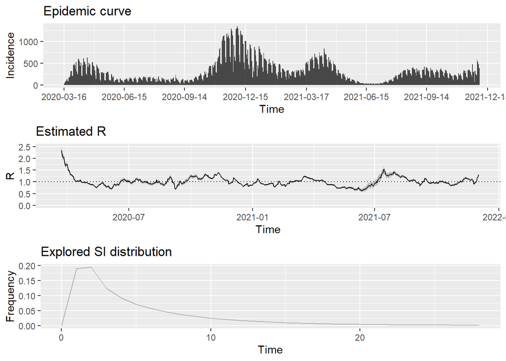

```r
library(EpiEstim)

# Daily case count by test result date
incidence_data <- list.files(path = "data/cases_by_date", full.names = TRUE) %>%
  last %>%
  read_csv(col_types = cols(collection_date = col_character(),
                            etl_timestamp = col_skip(),
                            negative = col_integer(),
                            positive = col_integer())) %>%
  filter(!is.na(positive) & (date(collection_date) >= date("2020-03-16"))) %>%
  mutate(dates = date(collection_date)) %>%
  arrange(dates) %>%
  mutate(positivity_rate = positive / (positive + negative)) %>%
  select(dates, positive, negative, positivity_rate) %>%
  filter(dates <= last(dates) - 3) # remove last 3 days considering lag in test results

# Plot incidence and effective reproductive number over time
# Serial interval mean and std estimates from: https://www.dhs.gov/publication/st-master-question-list-covid-19
res_parametric_si <- estimate_R(incidence_data %>%
                                  select(dates, I = positive),
                                method="parametric_si",
                                config = make_config(list(mean_si = 5.29, std_si = 5.32)))
```

From the epidemic curve and estimated instantaneous reproduction number, it looks like there’s no obvious change before and after the vaccination having been distributed. It might because not enough people has accepted taking vaccination.

Then I compare the daily cases and hospitaliztion rate for different age group.

```r
# aggregate cases trend of different age group

rm(list = ls())

library(ggplot2)

dates <- seq(as.Date("2020-06-04"), as.Date("2021-11-30"), by=1)

age <- data.frame()
# colnames(age) <- c("date","0_19","20_34","35_54","55_74","74+")

for (date in as.list(dates)){

  file.name = paste("data/cases_by_age/" , "covid_cases_by_age_" , date , ".csv", sep = "");
  df <- read.csv(file = file.name)
  age[nrow(age)+1, "date"] = as.character(date);

  for(i in 1:nrow(df)) {
    row <- df[i,]
    age[nrow(age), row$age] <- row$count;
  }

}
age$date <- as.Date(as.character(age$date))

rownames(age) <- age$date
head (age[,1:6], n = 5L)
```

```
##                  date 20-34 55-74  75+ <20 35-54
## 2020-06-04 2020-06-04  5520  6605 2895 866  7388
## 2020-06-05 2020-06-05  5556  6639 2906 872  7426
## 2020-06-06 2020-06-06  5580  6681 2912 879  7468
## 2020-06-07 2020-06-07  5580  6681 2912 879  7468
## 2020-06-08 2020-06-08  5622  6727 2919 901  7513
```

```r
colors <- c("<20" = "green1", "20-34" = "red", "35-54" = "deepskyblue1", "55-74"="sienna4", "75+"="purple")

age_plot <- ggplot(age, aes(x = date)) +
  geom_smooth(aes(y = `<20`, color = "<20"), span = 0.1, method = 'loess', formula ='y ~ x') +
  geom_smooth(aes(y = `20-34`, color = "20-34"), span = 0.1, method = 'loess', formula ='y ~ x') +
  geom_smooth(aes(y = `35-54`, color = "35-54"), span = 0.1, method = 'loess', formula ='y ~ x') +
  geom_smooth(aes(y = `55-74`, color = "55-74"), span = 0.1, method = 'loess', formula ='y ~ x') +
  geom_smooth(aes(y = `75+`, color = "75+"), span = 0.1, method = 'loess', formula ='y ~ x') +
  labs (x = 'Time',
        y = 'Aggregated count',
        color = "Legend") +
  scale_color_manual(values = colors)
```

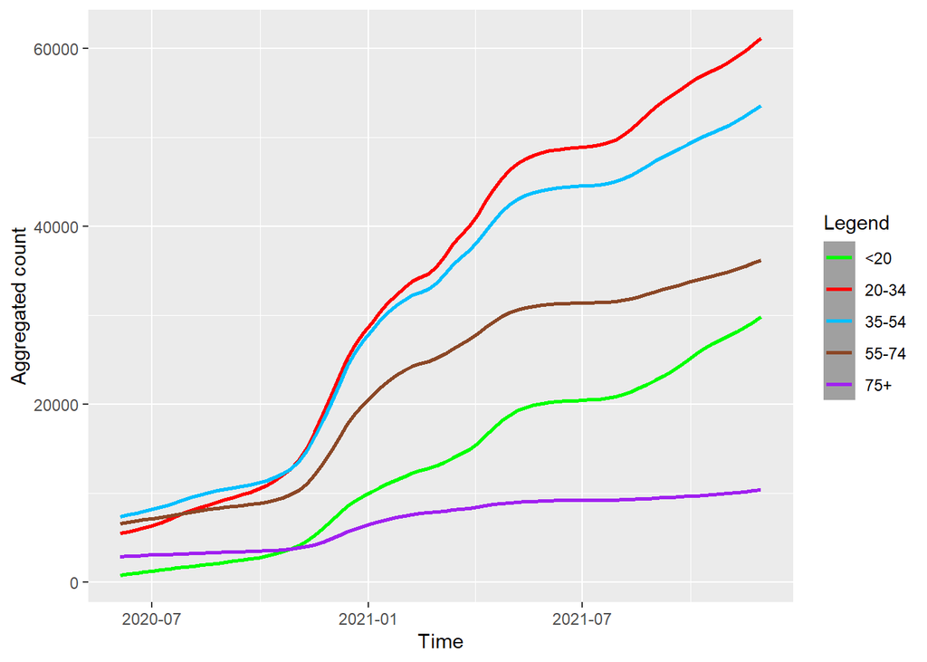

```r
age_plot
```

```r
# calculate hospitalization rate for each age group

rm(list = ls())

library(tidyverse)
library(ggplot2)

dates <- seq(as.Date("2020-08-14"), as.Date("2021-11-30"), by=1)

age <- data.frame(matrix(ncol = 11, nrow = 0))
colnames(age) <- c("date","0_19_yes","20_34_yes","35_54_yes","55_74_yes","74+_yes",
                   "0_19_no","20_34_no","35_54_no","55_74_no","74+_no")

for (date in as.list(dates)){

  file.name = paste("data/hospitalizations_by_age/" , "covid_hospitalizations_by_age_" , date , ".csv", sep = "");
  df <- read.csv(file = file.name)
  age[nrow(age)+1, "date"] = as.character(date);
  age[nrow(age), 2] <- df[df$age=="<20","Yes"]
  age[nrow(age), 3] <- df[df$age=="20-34","Yes"]
  age[nrow(age), 4] <- df[df$age=="35-54","Yes"]
  age[nrow(age), 5] <- df[df$age=="55-74","Yes"]
  age[nrow(age), 6] <- df[df$age=="75+","Yes"]

  age[nrow(age), 7] <- df[df$age=="<20","NO_UNKNOWN"];
  age[nrow(age), 8] <- df[df$age=="20-34","NO_UNKNOWN"];
  age[nrow(age), 9] <- df[df$age=="35-54","NO_UNKNOWN"];
  age[nrow(age), 10] <- df[df$age=="55-74","NO_UNKNOWN"];
  age[nrow(age), 11] <- df[df$age=="75+","NO_UNKNOWN"];


}

age$date <- as.Date(as.character(age$date))
rownames(age) <- age$date

age <- age %>%
  mutate(rate1 = age$"0_19_yes" / (age$"0_19_yes" + age$"0_19_no")) %>%
  mutate(rate2 = age$"20_34_yes" / (age$"20_34_yes" + age$"20_34_no")) %>%
  mutate(rate3 = age$"35_54_yes" / (age$"35_54_yes" + age$"35_54_no")) %>%
  mutate(rate4 = age$"55_74_yes" / (age$"55_74_yes" + age$"55_74_no")) %>%
  mutate(rate5 = age$"74+_yes" / (age$"74+_yes" + age$"74+_no"))

head (age , n = 5L)
```

```
##                  date 0_19_yes 20_34_yes 35_54_yes 55_74_yes 74+_yes 0_19_no 20_34_no 35_54_no 55_74_no 74+_no      rate1      rate2     rate3     rate4     rate5
## 2020-08-14 2020-08-14      115       692      1520      2675    1529    1876     7918     8462     5455   1799 0.05775992 0.08037166 0.1522741 0.3290283 0.4594351
## 2020-08-15 2020-08-15      115       693      1520      2676    1530    1896     7957     8505     5477   1801 0.05718548 0.08011561 0.1516209 0.3282227 0.4593215
## 2020-08-16 2020-08-16      115       693      1520      2676    1530    1896     7957     8505     5477   1801 0.05718548 0.08011561 0.1516209 0.3282227 0.4593215
## 2020-08-17 2020-08-17      115       693      1520      2676    1530    1921     8002     8560     5503   1811 0.05648330 0.07970098 0.1507937 0.3271794 0.4579467
## 2020-08-18 2020-08-18      115       695      1522      2678    1530    1930     8031     8586     5510   1818 0.05623472 0.07964703 0.1505738 0.3270640 0.4569892
```

```r
colors <- c("<20" = "green1", "20-34" = "red", "35-54" = "deepskyblue1", "55-74"="sienna4", "75+"="purple")

age_rate_plot <- ggplot(age, aes(x = date)) +
  geom_smooth(aes(y = `rate1`, color = "<20"), span = 0.1, se = FALSE, method = 'loess', formula ='y ~ x') +
  geom_smooth(aes(y = `rate2`, color = "20-34"), span = 0.1, se = FALSE, method = 'loess', formula ='y ~ x' ) +
  geom_smooth(aes(y = `rate3`, color = "35-54"), span = 0.1, se = FALSE, method = 'loess', formula ='y ~ x') +
  geom_smooth(aes(y = `rate4`, color = "55-74"), span = 0.1, se = FALSE, method = 'loess', formula ='y ~ x') +
  geom_smooth(aes(y = `rate5`, color = "75+"), span = 0.1, se = FALSE, method = 'loess', formula ='y ~ x') +
  labs (x = 'Time',
        y = 'Hospitalization Rate',
        color = "Legend") +
  scale_color_manual(values = colors)
```

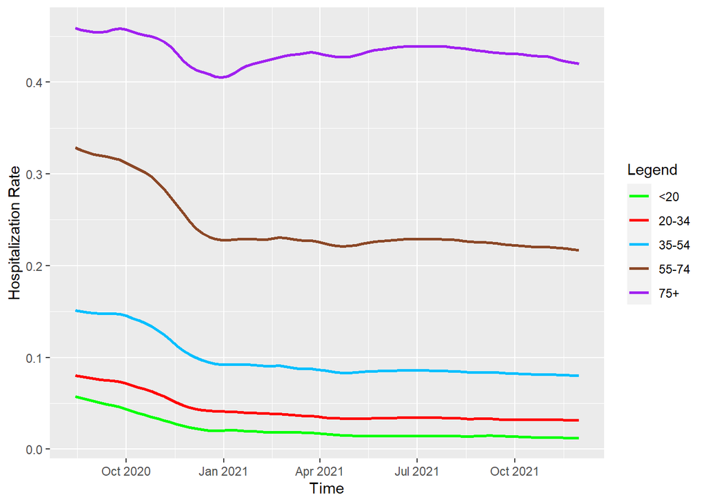

```r
age_rate_plot
```

Then I do the same thing for different race groups.

```r
rm(list = ls())

library(ggplot2)

dates <- seq(as.Date("2020-08-14"), as.Date("2021-11-30"), by=1)

race <- data.frame()

for (date in as.list(dates)){

  file.name = paste("data/cases_by_race/" , "covid_cases_by_race_" , date , ".csv", sep = "");
  df <- read.csv(file = file.name)
  race[nrow(race)+1, "date"] = as.character(date);

  for(i in 1:nrow(df)) {
    row <- df[i,]
    if (!is.na(row$racial_identity))
      race[nrow(race), tolower(row$racial_identity)] <- row$count;
  }
}

race$date <- as.Date(as.character(race$date))
rownames(race) <- race$date
head (race, n=5)
```

```
##                  date white other african pacific islander native american unknown asian hispanic african american american indian decline black declined to specify samoan
## 2020-08-14 2020-08-14  5082  1147       8               15              30     262  1069     3672            14142              NA      NA    NA                  NA     NA
## 2020-08-15 2020-08-15  5092  1147       8               15              30     270  1068     3681            14159              NA      NA    NA                  NA     NA
## 2020-08-16 2020-08-16  5092  1147       8               15              30     270  1068     3681            14159              NA      NA    NA                  NA     NA
## 2020-08-17 2020-08-17  5108  1149       8               15              30     270  1070     3688            14185              NA      NA    NA                  NA     NA
## 2020-08-18 2020-08-18  5114  1152       8               15              30     269  1070     3694            14195              NA      NA    NA                  NA     NA
```

```r
colors <- c("White" = "brown4", "Hispanic" = "coral", "Asian" = "red", "African American"="blue")

race_plot <- ggplot(race, aes(x = date)) +
  geom_smooth(aes(y = `white`, color = "White"), span = 0.1, se = FALSE, method = 'loess', formula ='y ~ x') +
  geom_smooth(aes(y = `hispanic`, color = "Hispanic"), span = 0.1, se = FALSE, method = 'loess', formula ='y ~ x') +
  geom_smooth(aes(y = `asian`, color = "Asian"), span = 0.1, se = FALSE, method = 'loess', formula ='y ~ x') +
  geom_smooth(aes(y = `african american`, color = "African American"), span = 0.1, se = FALSE, method = 'loess', formula ='y ~ x') +
  labs (x = 'date',
        y = 'aggregated count',
        color = "Legend") +
  scale_color_manual(values = colors)
```

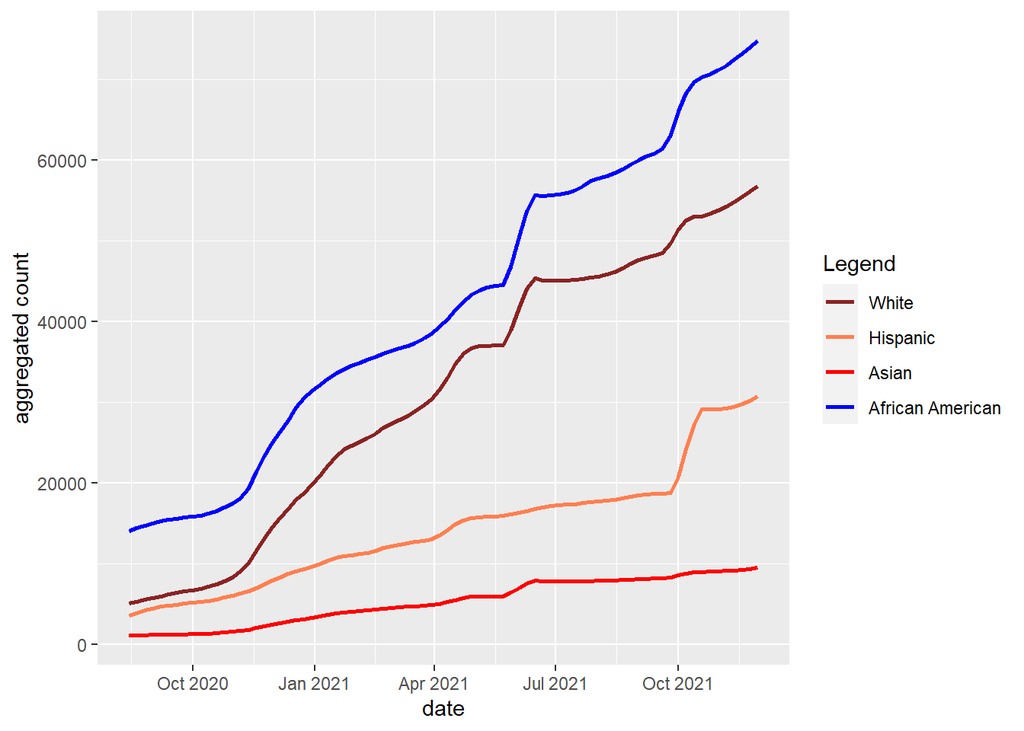

```r
race_plot
```

```r
rm(list = ls())

library(ggplot2)

dates <- seq(as.Date("2020-08-14"), as.Date("2021-11-30"), by=1)

race.hos <- data.frame()
race.nohos <- data.frame()

rate <- data.frame();

for (date in as.list(dates)){

  file.name = paste("data/hospitalizations_by_race/" , "covid_hospitalizations_by_race_" , date , ".csv", sep = "");
  df <- read.csv(file = file.name)
  race.hos[nrow(race.hos)+1, "date"] = as.character(date);
  race.nohos[nrow(race.nohos)+1, "date"] = as.character(date);
  rate[nrow(rate)+1, "date"] = as.character(date);

  for(i in 1:nrow(df)) {
    row <- df[i,]
    if (!is.na(row$racial_identity)){
      race.hos[nrow(race.hos), tolower(row$racial_identity)] <- row$Yes;
      race.nohos[nrow(race.nohos), tolower(row$racial_identity)] <- row$NO_UNKNOWN;
      rate[nrow(rate), tolower(row$racial_identity)] <- row$Yes/(row$Yes + row$NO_UNKNOWN);
    }
  }
}

rownames(race.hos) <- race.hos$date
rownames(race.nohos) <- race.nohos$date

race.hos$date <- as.Date(as.character(race.hos$date))
race.nohos$date <- as.Date(as.character(race.nohos$date))
rate$date <- as.Date(as.character(rate$date))

head (rate, n = 5L)
```

```
##         date  hispanic     white   unknown native american     asian african american pacific islander     other decline american indian declined to specify samoan
## 1 2020-08-14 0.2459150 0.2182212 0.2748092       0.1333333 0.2394761        0.2677132              0.4 0.2173160      NA              NA                  NA     NA
## 2 2020-08-15 0.2453138 0.2181854 0.2703704       0.1333333 0.2397004        0.2673918              0.4 0.2173160      NA              NA                  NA     NA
## 3 2020-08-16 0.2453138 0.2181854 0.2703704       0.1333333 0.2397004        0.2673918              0.4 0.2173160      NA              NA                  NA     NA
## 4 2020-08-17 0.2448482 0.2175020 0.2703704       0.1333333 0.2392523        0.2669017              0.4 0.2169404      NA              NA                  NA     NA
## 5 2020-08-18 0.2444505 0.2178334 0.2676580       0.1333333 0.2392523        0.2667841              0.4 0.2172414      NA              NA                  NA     NA
```

```r
colors <- c("White" = "brown4", "Hispanic" = "coral", "Asian" = "red", "African American"="blue")

race_rate_plot <- ggplot(rate, aes(x = date)) +
  geom_smooth(aes(y = `white`, color = "White"), span = 0.1, se = FALSE, method = 'loess', formula ='y ~ x') +
  geom_smooth(aes(y = `hispanic`, color = "Hispanic"), span = 0.1, se = FALSE, method = 'loess', formula ='y ~ x') +
  geom_smooth(aes(y = `asian`, color = "Asian"), span = 0.1, se = FALSE, method = 'loess', formula ='y ~ x') +
  geom_smooth(aes(y = `african american`, color = "African American"), span = 0.1, se = FALSE, method = 'loess', formula ='y ~ x') +
  labs (x = 'date',
        y = 'rate',
        color = "Legend") +
  scale_color_manual(values = colors)
```

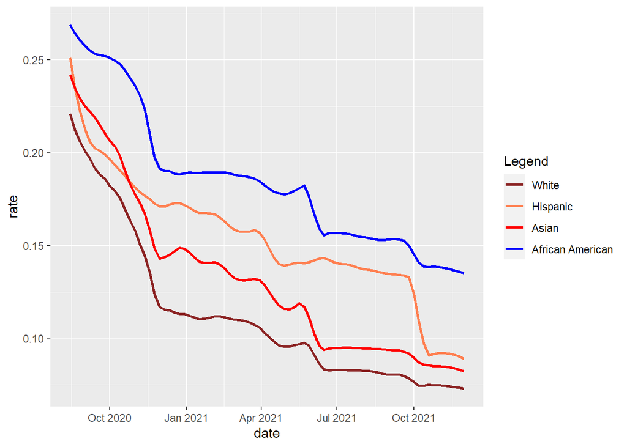

```r
race_rate_plot
```

From the previous two charts, we can see the speed of disease spreading was not dramatically decreased by the vaccination. However, hospitalization rate obviously decreased for most race groups after the vaccines have been created.

# Conclusion

# Future Plan

To make the result more convencing, there are other analysis to be done: - statistical analysis - compare vaccination with other factors which cause similar results. E.g. lock down, masking face, social distance and season change. - collect data for how many people use what method to prevent covid. How much does the vaccination contribute in them

# References

1. Data from Philadelphia Open Data Program: https://github.com/ambientpointcorp/covid19-philadelphia
2. R in Action, Third Edition by Robert I. Kabacoff